# High NAAPS Deposition vs. High SP2 Observations

Ella Hall

2025-10-08

# Goals of Analysis

The goals here are to:

1. Find high concentration periods from the NAAPS dataset (specifically smoke).
2. Find high concentration periods in the SP2 dataset for incandescent mass, particle concentration, total mass, and scattering particle concentration
3. See how well the dates line up
4. Using the SP2 dataset, see what wind direction most high concentration days are coming from
5. Use this to find some days that represent long-range transport and some that represent local contamination

# Load the Data

**Packages**

```r
library(dplyr)
library(tidyr)
library(lubridate)
library(ggplot2)
library(scales)
library(PNWColors)
library(stringr)
library(purrr)
library(patchwork)
```

**Data**

*All SP2 Stats – minutely*

```r
AllStats <- read.csv("All_SP2_Statistics_Seconds.csv")
  # Drop NA rows
  AllStats <- na.omit(AllStats)

# split the `Date_Time` column to just have the date
AllStats <- AllStats %>%
  separate(Date_Time, into = c("Date", "Time_Min"), sep = " ")
head(AllStats)
```

```
##       Date Time_Min SecondsOfDay IncandParticleConc ScatteringParticleConc
## 1 20240619 00:01:01           61            4.82967                98.6885
## 2 20240619 00:02:01          121            4.54950                93.3635
## 3 20240619 00:03:01          181            4.39733                99.3720
## 4 20240619 00:04:01          241            0.00000                 0.0000
## 5 20240619 00:05:01          301            0.00000                 0.0000
## 6 20240619 00:06:01          361            4.21400                94.9780
##   IncandMassConc TotalMass dbarScatter dmvdScatter dbarIncnd dmvdIncnd
## 1        4.28333   6.60733     225.697     330.066   78.7314   247.007
## 2        2.95300   4.55583     238.343     342.402   76.2392   172.690
## 3        4.38100   6.76300     232.757     340.525   78.6810   334.639
## 4        3.72467   5.75133     225.671     320.942   76.2503   293.668
## 5        2.98500   4.60800     227.569     322.375   78.2073   154.689
## 6        2.89850   4.47283     226.820     323.994   76.1715   204.336
##   coatingTotal coatingModeEOD ambT ambWS ambWD ambRH
## 1      106.400        52.0616  6.0   2.9   338    66
## 2      100.962        53.5032  5.9   2.7   323    67
## 3      107.211        56.5070  5.8   2.2   328    68
## 4      101.756        38.5515  6.1   2.2   312    68
## 5      101.455        44.1925  5.9   2.1   308    67
## 6      102.562        54.9846  5.9   2.2   311    67
```

```r
# Clean up date format
AllStats$Date <- as.Date(as.character(AllStats$Date), format = "%Y%m%d")
```

*SP2 and Flight Log merged*

```r
SP2_FlightLogMerged <- read.csv("SP2_FlightLogMerged.csv")
SP2_FlightLogMerged$Date <- as.Date(SP2_FlightLogMerged$Date)
```

**All SP2 Stats - DAILY**

```r
DailySP2 <- SP2_FlightLogMerged %>%
mutate(
    DateTime = as.POSIXct(paste(Date, Time_Min), format = "%Y-%m-%d %H:%M:%S"))
```

Then, compute daily averages for the following variables:

- Average incandescent particle concentration (# / cm^3)
- Average incandescent mass concentration (ng / m^3)
- Average total mass (fg) (femtograms)
- Scattering particle concentration (#/cm^3)

```r
DailySP2 <- DailySP2 %>%
  group_by(Date) %>%
  summarize(
    DailyIncandParticle = mean(IncandParticleConc, na.rm = TRUE),
    DailyIncandMass = mean(IncandMassConc, na.rm = TRUE),
    DailyTotMass = mean(TotalMass, na.rm = TRUE),
    DailyScatteringParticle = mean(ScatteringParticleConc, na.rm = TRUE),
    DailyCoatingTotal = mean(coatingTotal, na.rm = TRUE),
    DailyCoatingMode = mean(coatingModeEOD),
    AvgWindDirection = mean(ambWD, na.rm = TRUE))

# convert to date format
DailySP2$Date <- as.Date(DailySP2$Date)
```

*Flight Log*

```r
FlightLog <- read.csv("FlightData_Cleaned.csv")
```

*NAAPS Data*

```r
Pituffik_NAAPS <- read.csv("Pituffik_SP2_NAAPS_Data.csv")
# Clean up date format
Pituffik_NAAPS$Date <- as.Date(Pituffik_NAAPS$Date)

Pituffik_SurfConc <- read.csv("PituffikSurfaceConcentrations_SP2.csv")
Pituffik_SurfConc$Date <- as.Date(Pituffik_SurfConc$Date)
```

**NAAPS, SP2 Merged**

```r
NAAPS_SP2_Merged <- DailySP2 %>%
  inner_join(Pituffik_SurfConc, by = "Date")
```

# 1. Find high concentration periods from the NAAPS dataset (specifically smoke).

I want to find some time periods when the NAAPS smoke deposition was especially high.

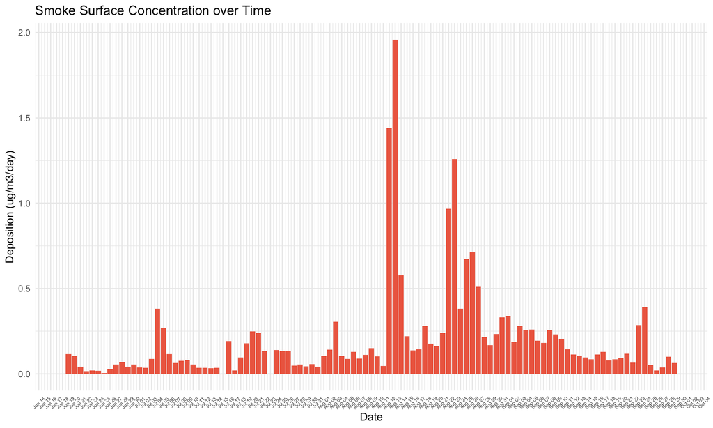

```r
ggplot(NAAPS_SP2_Merged, aes(x = Date, y = smoke_conc_sfc)) +
  geom_bar(stat = "identity", fill = "coral2") +
  scale_x_date(date_breaks = "1 day", date_labels = "%b %d") +
  labs(
    title = "Smoke Surface Concentration over Time",
    x = "Date",
    y = "Deposition (ug/m3/day)"
  ) +
  theme_minimal() +
  theme(axis.text.x = element_text(angle = 45, vjust = 0.5, size = 5))
```

```r
AverageSmokeSfcConc <- mean(NAAPS_SP2_Merged$smoke_conc_sfc)
```

I will flag days that higher-than-average deposition:

```r
AboveAverageSmoke <- NAAPS_SP2_Merged %>%
  mutate(
    HighSmoke = smoke_conc_sfc > AverageSmokeSfcConc
  )
```

And plot to see when above-average deposition is happening.

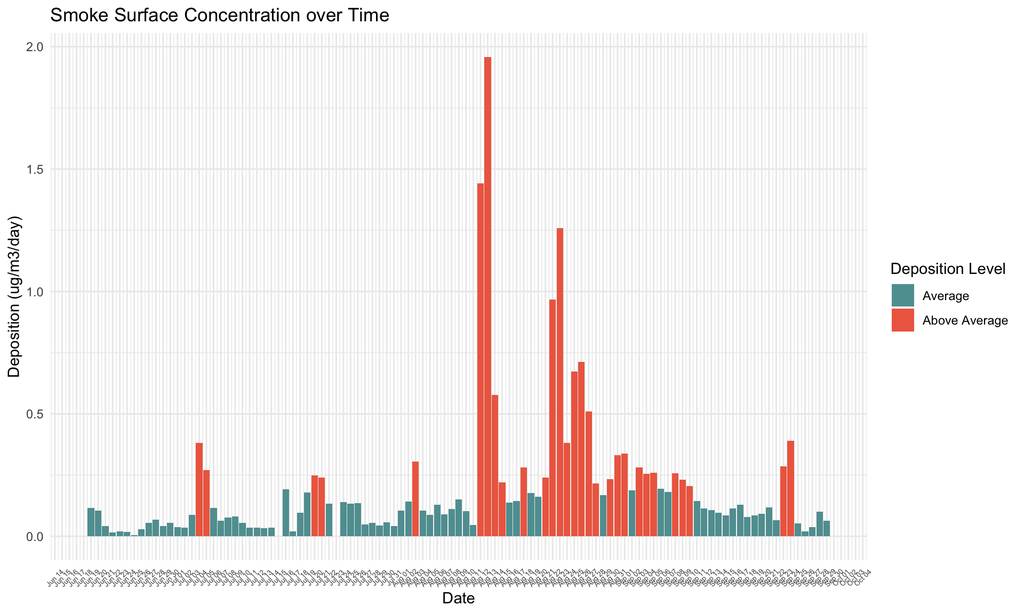

```r
ggplot(AboveAverageSmoke, aes(x = Date, y = smoke_conc_sfc, fill = HighSmoke)) +
  geom_bar(stat = "identity") +
  scale_fill_manual(
    values = c("FALSE" = "cadetblue", "TRUE" = "coral2"),  # normal vs above-average
    labels = c("Average", "Above Average")
  ) +
  scale_x_date(date_breaks = "1 day", date_labels = "%b %d") +
  labs(
    title = "Smoke Surface Concentration over Time",
    x = "Date",
    y = "Deposition (ug/m3/day)",
    fill = "Deposition Level"
  ) +
  theme_minimal() +
  theme(axis.text.x = element_text(angle = 45, vjust = 0.5, size = 5))
```

Then, I will make a dataset that only includes high deposition days and low deposition days.

```r
HighSmokeDays <- AboveAverageSmoke %>%
  filter(HighSmoke == TRUE)

LowSmokeDays <- AboveAverageSmoke %>%
  filter(HighSmoke == FALSE)
```

# 2. Find high concentration periods in the SP2 dataset

## Incandescent Mass

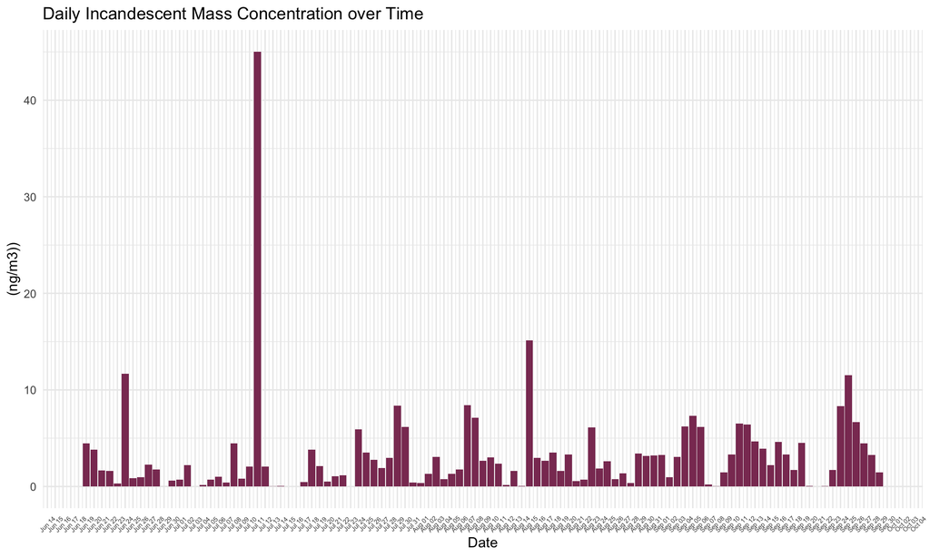

```r
ggplot(NAAPS_SP2_Merged, aes(x = Date, y = DailyIncandMass)) +
  geom_bar(stat = "identity", fill = "hotpink4") +
  scale_x_date(date_breaks = "1 day", date_labels = "%b %d") +
  labs(
    title = "Daily Incandescent Mass Concentration over Time",
    x = "Date",
    y = "(ng/m3))"
  ) +
  theme_minimal() +
  theme(axis.text.x = element_text(angle = 45, vjust = 0.5, size = 5))
```

```r
AverageIncandMass <- mean(NAAPS_SP2_Merged$DailyIncandMass)
```

I will flag days that higher-than-average incandescent mass concentration:

```r
AboveAverageIncandMass <- NAAPS_SP2_Merged %>%
  mutate(
    HighIncandMassConc = DailyIncandMass > AverageIncandMass
  )
```

And plot to see when above-average deposition is happening.

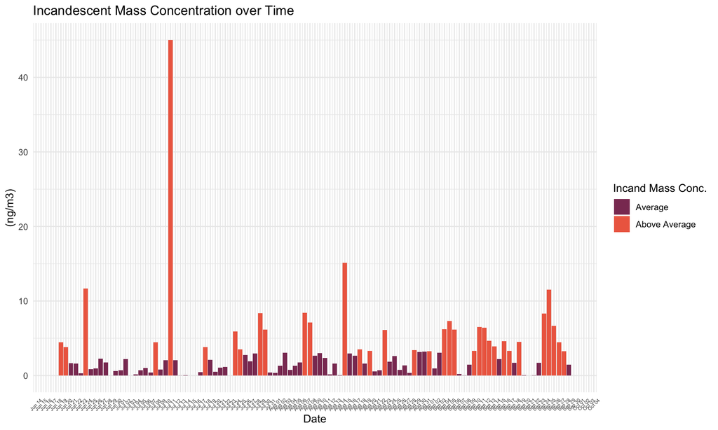

```r
ggplot(AboveAverageIncandMass, aes(x = Date, y = DailyIncandMass, fill = HighIncandMassConc)) +
  geom_bar(stat = "identity") +
  scale_fill_manual(
    values = c("FALSE" = "hotpink4", "TRUE" = "coral2"),  # normal vs above-average
    labels = c("Average", "Above Average")
  ) +
  scale_x_date(date_breaks = "1 day", date_labels = "%b %d") +
  labs(
    title = "Incandescent Mass Concentration over Time",
    x = "Date",
    y = "(ng/m3)",
    fill = "Incand Mass Conc."
  ) +
  theme_minimal() +
  theme(axis.text.x = element_text(angle = 45, vjust = 0.5, size = 5))
```

Then, I will make a dataset that only includes high deposition days and low deposition days.

```r
HighIncandMass <- AboveAverageIncandMass %>%
  filter(HighIncandMassConc == TRUE)

LowIncandMass <- AboveAverageIncandMass %>%
  filter(HighIncandMassConc == FALSE)
```

## Incandescent Particle Concentration

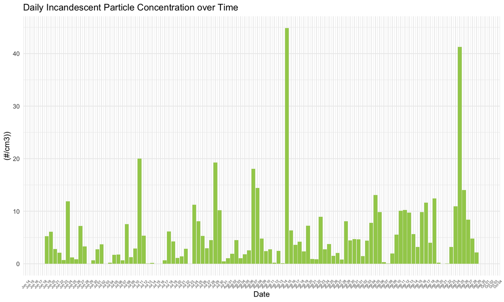

```r
ggplot(NAAPS_SP2_Merged, aes(x = Date, y = DailyIncandParticle)) +
  geom_bar(stat = "identity", fill = "darkolivegreen3") +
  scale_x_date(date_breaks = "1 day", date_labels = "%b %d") +
  labs(
    title = "Daily Incandescent Particle Concentration over Time",
    x = "Date",
    y = "(#/cm3))"
  ) +
  theme_minimal() +
  theme(axis.text.x = element_text(angle = 45, vjust = 0.5, size = 5))
```

```r
AverageIncandParticle <- mean(NAAPS_SP2_Merged$DailyIncandParticle)
```

I will flag days that higher-than-average incandescent Particle concentration:

```r
AboveAverageIncandParticle <- NAAPS_SP2_Merged %>%
  mutate(
    HighIncandParticleConc = DailyIncandParticle > AverageIncandParticle
  )
```

And plot to see when above-average deposition is happening.

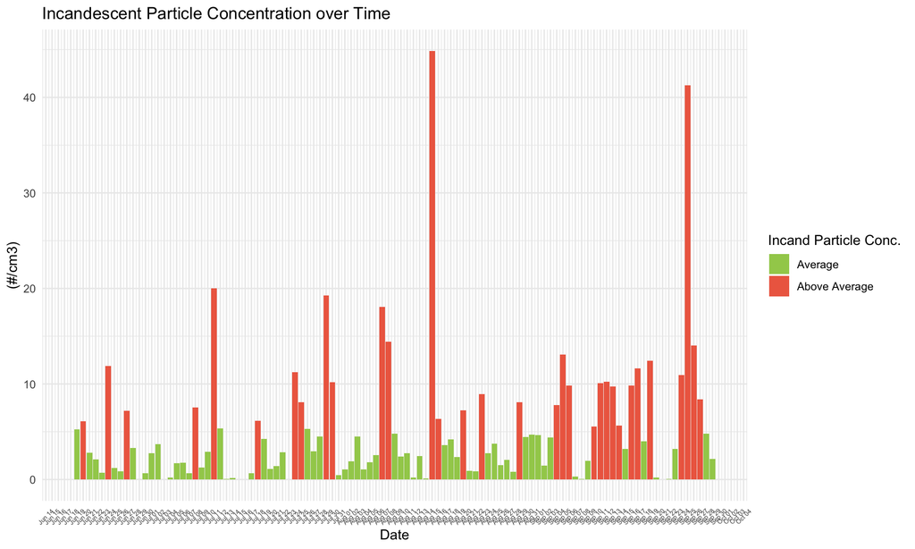

```r
ggplot(AboveAverageIncandParticle, aes(x = Date, y = DailyIncandParticle, fill = HighIncandParticleConc)) +
  geom_bar(stat = "identity") +
  scale_fill_manual(
    values = c("FALSE" = "darkolivegreen3", "TRUE" = "coral2"),  # normal vs above-average
    labels = c("Average", "Above Average")
  ) +
  scale_x_date(date_breaks = "1 day", date_labels = "%b %d") +
  labs(
    title = "Incandescent Particle Concentration over Time",
    x = "Date",
    y = "(#/cm3)",
    fill = "Incand Particle Conc."
  ) +
  theme_minimal() +
  theme(axis.text.x = element_text(angle = 45, vjust = 0.5, size = 5))
```

Then, I will make a dataset that only includes high deposition days and low deposition days.

```r
HighIncandParticle <- AboveAverageIncandParticle %>%
  filter(HighIncandParticleConc == TRUE)

LowIncandParticle <- AboveAverageIncandParticle %>%
  filter(HighIncandParticleConc == FALSE)
```

## Total Mass

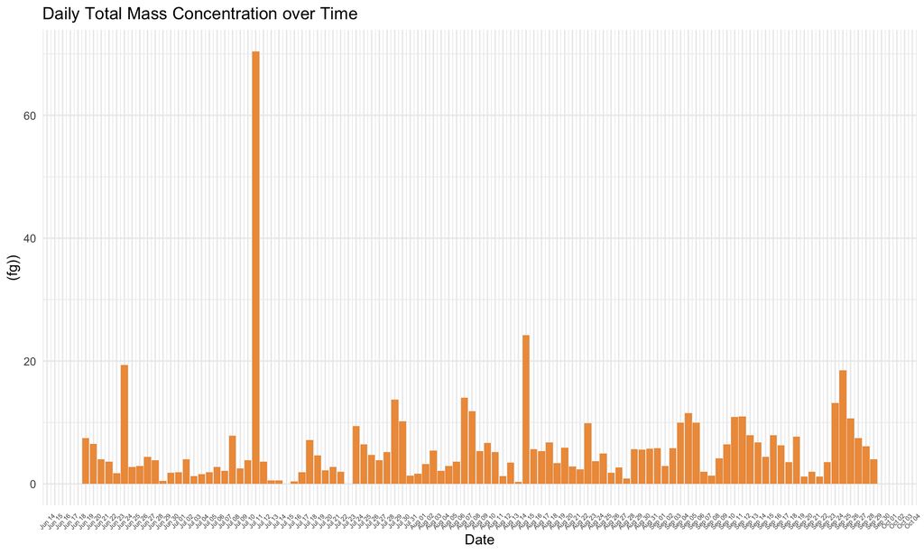

```r
ggplot(NAAPS_SP2_Merged, aes(x = Date, y = DailyTotMass)) +
  geom_bar(stat = "identity", fill = "tan2") +
  scale_x_date(date_breaks = "1 day", date_labels = "%b %d") +
  labs(
    title = "Daily Total Mass Concentration over Time",
    x = "Date",
    y = "(fg))"
  ) +
  theme_minimal() +
  theme(axis.text.x = element_text(angle = 45, vjust = 0.5, size = 5))
```

```r
AverageTotMass <- mean(NAAPS_SP2_Merged$DailyTotMass)
```

I will flag days that higher-than-average Totescent mass concentration:

```r
AboveAverageTotMass <- NAAPS_SP2_Merged %>%
  mutate(
    HighTotMassConc = DailyTotMass > AverageTotMass
  )
```

And plot to see when above-average deposition is happening.

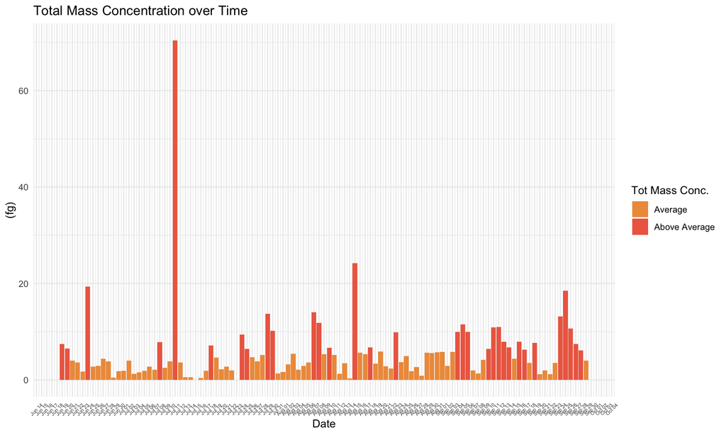

```r
ggplot(AboveAverageTotMass, aes(x = Date, y = DailyTotMass, fill = HighTotMassConc)) +
  geom_bar(stat = "identity") +
  scale_fill_manual(
    values = c("FALSE" = "tan2", "TRUE" = "coral2"),  # normal vs above-average
    labels = c("Average", "Above Average")
  ) +
  scale_x_date(date_breaks = "1 day", date_labels = "%b %d") +
  labs(
    title = "Total Mass Concentration over Time",
    x = "Date",
    y = "(fg)",
    fill = "Tot Mass Conc."
  ) +
  theme_minimal() +
  theme(axis.text.x = element_text(angle = 45, vjust = 0.5, size = 5))
```

Then, I will make a dataset that only includes high deposition days and low deposition days.

```r
HighTotMass <- AboveAverageTotMass %>%
  filter(HighTotMassConc == TRUE)

LowTotMass <- AboveAverageTotMass %>%
  filter(HighTotMassConc == FALSE)
```

## Scattering Particle Concentration

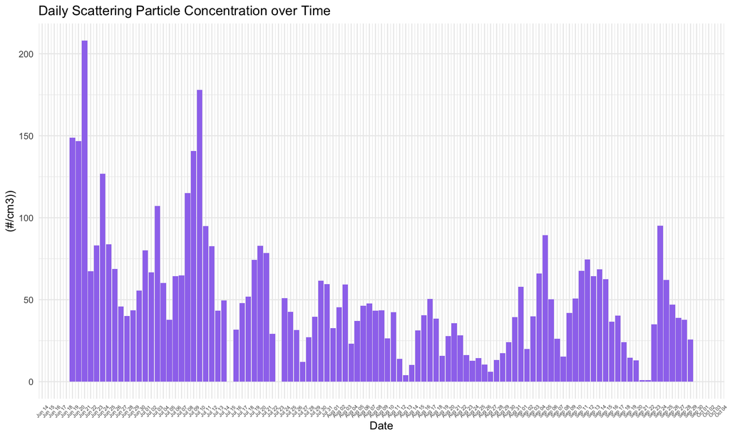

```r
ggplot(NAAPS_SP2_Merged, aes(x = Date, y = DailyScatteringParticle)) +
  geom_bar(stat = "identity", fill = "mediumpurple2") +
  scale_x_date(date_breaks = "1 day", date_labels = "%b %d") +
  labs(
    title = "Daily Scattering Particle Concentration over Time",
    x = "Date",
    y = "(#/cm3))"
  ) +
  theme_minimal() +
  theme(axis.text.x = element_text(angle = 45, vjust = 0.5, size = 5))
```

```r
AverageScatteringParticle <- mean(NAAPS_SP2_Merged$DailyScatteringParticle)
```

I will flag days that higher-than-average Scattering Particle concentration:

```r
AboveAverageScatteringParticle <- NAAPS_SP2_Merged %>%
  mutate(
    HighScatteringParticleConc = DailyScatteringParticle > AverageScatteringParticle
  )
```

And plot to see when above-average deposition is happening.

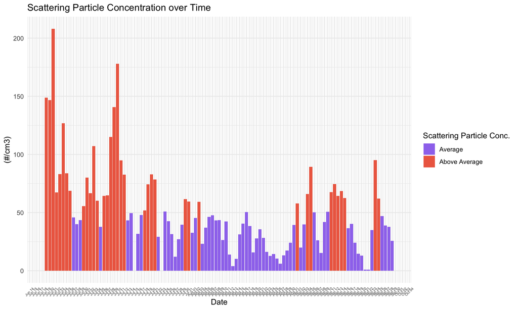

```r
ggplot(AboveAverageScatteringParticle, aes(x = Date, y = DailyScatteringParticle, fill = HighScatteringParticleConc)) +
  geom_bar(stat = "identity") +
  scale_fill_manual(
    values = c("FALSE" = "mediumpurple2", "TRUE" = "coral2"),  # normal vs above-average
    labels = c("Average", "Above Average")
  ) +
  scale_x_date(date_breaks = "1 day", date_labels = "%b %d") +
  labs(
    title = "Scattering Particle Concentration over Time",
    x = "Date",
    y = "(#/cm3)",
    fill = "Scattering Particle Conc."
  ) +
  theme_minimal() +
  theme(axis.text.x = element_text(angle = 45, vjust = 0.5, size = 5))
```

Then, I will make a dataset that only includes high deposition days and low deposition days.

```r
HighScatteringParticle <- AboveAverageScatteringParticle %>%
  filter(HighScatteringParticleConc == TRUE)

LowScatteringParticle <- AboveAverageScatteringParticle %>%
  filter(HighScatteringParticleConc == FALSE)
```

# 3. See how well the dates line up

I want to compare the high NAAPS data to the high SP2 data to see how well they are correlated.

## Incandescent Mass Concentration

```r
HighIncandMass <- HighSmokeDays %>%
  mutate(OverlapWithSmoke = Date %in% HighIncandMass$Date)
```

```r
sum(HighIncandMass$OverlapWithSmoke == TRUE)
```

```
## [1] 8
```

There were 8 days where both were high.

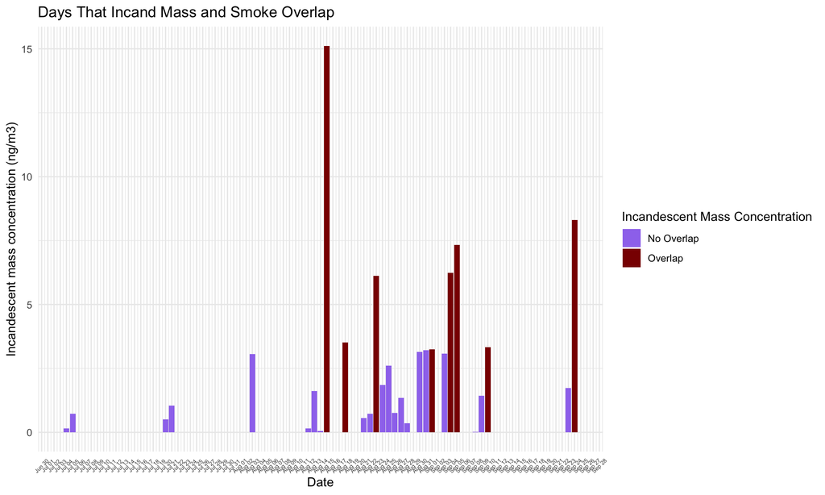

```r
ggplot(HighIncandMass, aes(x = Date, y = DailyIncandMass, fill = OverlapWithSmoke)) +
  geom_bar(stat = "identity") +
  scale_fill_manual(
    values = c("FALSE" = "mediumpurple2", "TRUE" = "red4"),  # normal vs above-average
    labels = c("No Overlap", "Overlap")
  ) +
  scale_x_date(date_breaks = "1 day", date_labels = "%b %d") +
  labs(
    title = "Days That Incand Mass and Smoke Overlap",
    x = "Date",
    y = "Incandescent mass concentration (ng/m3)",
    fill = "Incandescent Mass Concentration"
  ) +
  theme_minimal() +
  theme(axis.text.x = element_text(angle = 45, vjust = 0.5, size = 5))
```

## Incandescent Particle Concentration

```r
HighIncandParticle <- HighSmokeDays %>%
  mutate(OverlapWithSmoke = Date %in% HighIncandParticle$Date)
```

```r
sum(HighIncandParticle$OverlapWithSmoke == TRUE)
```

```
## [1] 6
```

There were 6 days where both were high.

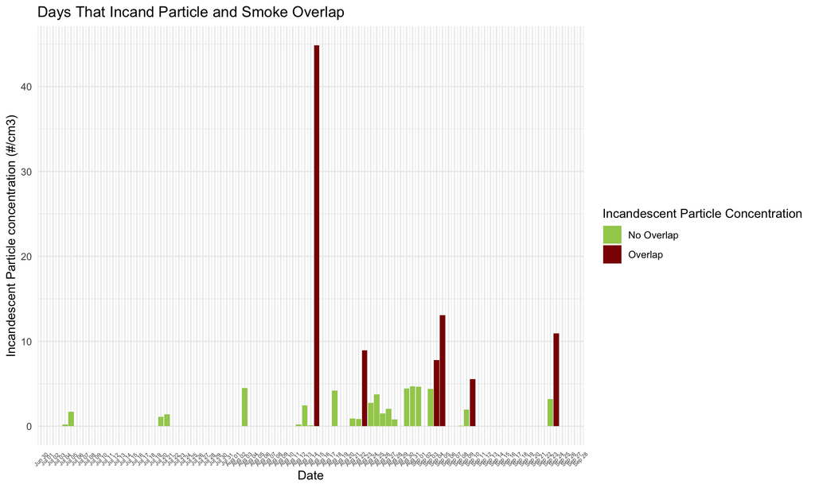

```r
ggplot(HighIncandParticle, aes(x = Date, y = DailyIncandParticle, fill = OverlapWithSmoke)) +
  geom_bar(stat = "identity") +
  scale_fill_manual(
    values = c("FALSE" = "darkolivegreen3", "TRUE" = "red4"),  # normal vs above-average
    labels = c("No Overlap", "Overlap")
  ) +
  scale_x_date(date_breaks = "1 day", date_labels = "%b %d") +
  labs(
    title = "Days That Incand Particle and Smoke Overlap",
    x = "Date",
    y = "Incandescent Particle concentration (#/cm3)",
    fill = "Incandescent Particle Concentration"
  ) +
  theme_minimal() +
  theme(axis.text.x = element_text(angle = 45, vjust = 0.5, size = 5))
```

The highest incandescent Particle concentrations do overlap with high smoke days! This is what I would expect!

## Total Mass Concentration

```r
HighTotalMass <- HighSmokeDays %>%
  mutate(OverlapWithSmoke = Date %in% HighTotMass$Date)
```

```r
sum(HighTotalMass$OverlapWithSmoke == TRUE)
```

```
## [1] 7
```

There were 7 days where both were high.

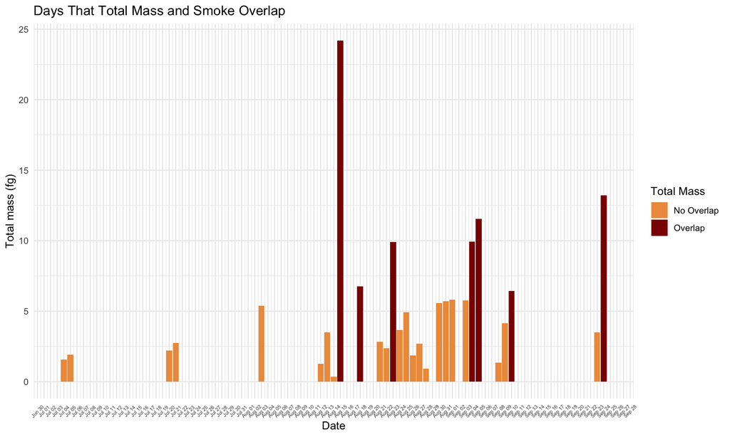

```r
ggplot(HighTotalMass, aes(x = Date, y = DailyTotMass, fill = OverlapWithSmoke)) +
  geom_bar(stat = "identity") +
  scale_fill_manual(
    values = c("FALSE" = "tan2", "TRUE" = "red4"),  # normal vs above-average
    labels = c("No Overlap", "Overlap")
  ) +
  scale_x_date(date_breaks = "1 day", date_labels = "%b %d") +
  labs(
    title = "Days That Total Mass and Smoke Overlap",
    x = "Date",
    y = "Total mass (fg)",
    fill = "Total Mass"
  ) +
  theme_minimal() +
   theme(axis.text.x = element_text(angle = 45, vjust = 0.5, size = 5))
```

# 4. Average Wind Direction for High Smoke Days

I want to figure out the average wind direction for high smoke days.

```r
HighSmokeDays <- HighSmokeDays %>%
  mutate(WindSector = cut(AvgWindDirection,
                          breaks = seq(0, 360, by = 45),
                          labels = c("N","NE","E","SE","S","SW","W","NW"),
                          include.lowest = TRUE))

table(HighSmokeDays$WindSector)
```

```
##
##  N NE  E SE  S SW  W NW
##  7  0  2 12  3  5  0  0
```

It looks like most of the high smoke days have wind coming from the Southeast. This could be indicative of smoke transport. SW has 5, which is more likely smoke transport. Then, 7 days were coming from the North, so this was likely local contamination.

# 5. Average Wind Direction for High Incandescent Particle Days

```r
HighIncandPartDays <- HighIncandParticle %>%
  mutate(WindSector = cut(AvgWindDirection,
                          breaks = seq(0, 360, by = 45),
                          labels = c("N","NE","E","SE","S","SW","W","NW"),
                          include.lowest = TRUE))

table(HighIncandPartDays$WindSector)
```

```
##
##  N NE  E SE  S SW  W NW
##  7  0  2 12  3  5  0  0
```

These look the same as high smoke days…

# 5. Local vs. Long-Range Transport

I am assuming that high smoke days where the wind was coming from the North were local contamination. Days where the wind was coming from the Southeast, South and Southwest are indicative of long-range smoke transport. I will separate these out into two datasets so I can comapre them.

```r
LongRangeTransport <- HighSmokeDays %>%
  filter(WindSector%in% c("S", "SE", "SW"))
```

```r
LocalContamination <- HighIncandPartDays %>%
  filter(WindSector == "N")
```

## Compare Attributes

I will compare how the data looks between local and long-range transport. Specifically, the coating thickness.

```r
summary(LocalContamination$DailyCoatingTotal)
```

```
##    Min. 1st Qu.  Median    Mean 3rd Qu.    Max.
##   7.403  12.909  15.643  19.103  23.683  37.490
```

```r
summary(LongRangeTransport$DailyCoatingTotal)
```

```
##    Min. 1st Qu.  Median    Mean 3rd Qu.    Max.
##   5.198  23.481  41.229  44.770  61.636  99.646
```

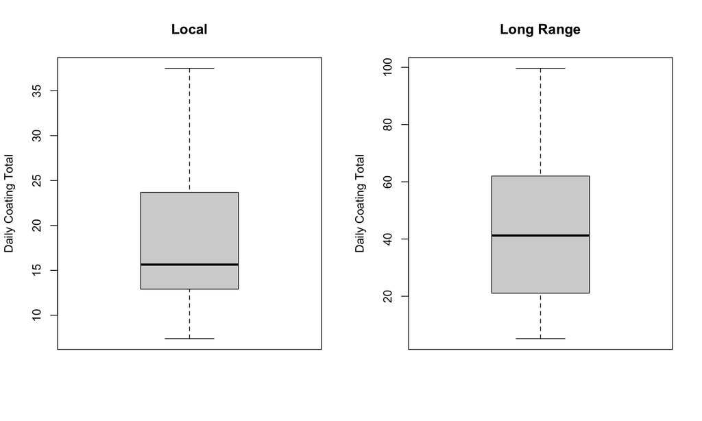

```r
par(mfrow = c(1, 2))  # 1 row, 2 columns

boxplot(LocalContamination$DailyCoatingTotal,
        main = "Local",
        ylab = "Daily Coating Total")

boxplot(LongRangeTransport$DailyCoatingTotal,
        main = "Long Range",
        ylab = "Daily Coating Total",
        ylim = range(c(LocalContamination$DailyCoatingTotal,
                       LongRangeTransport$DailyCoatingTotal), na.rm = TRUE))
```

The median coating total for local contamination is MUCH lower!! This makes sense since during long-range transport, the particles are picking up more “stuff”

```r
summary(LocalContamination$DailyCoatingMode)
```

```
##    Min. 1st Qu.  Median    Mean 3rd Qu.    Max.
##   56.26   58.82   59.46   58.96   59.67   60.04
```

```r
summary(LongRangeTransport$DailyCoatingMode)
```

```
##    Min. 1st Qu.  Median    Mean 3rd Qu.    Max.
##   51.70   56.52   61.48   60.13   62.97   67.12
```

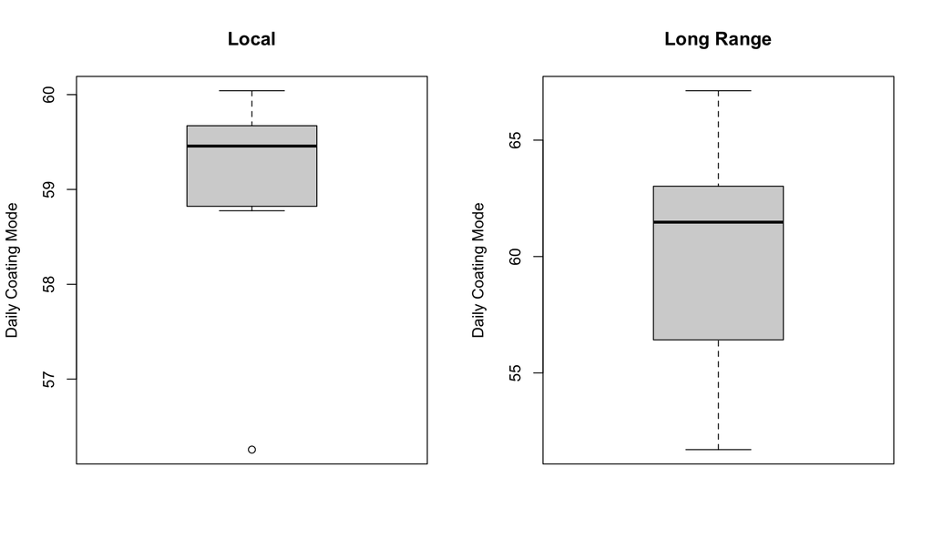

```r
par(mfrow = c(1, 2))  # 1 row, 2 columns

boxplot(LocalContamination$DailyCoatingMode,
        main = "Local",
        ylab = "Daily Coating Mode")

boxplot(LongRangeTransport$DailyCoatingMode,
        main = "Long Range",
        ylab = "Daily Coating Mode",
        ylim = range(c(LocalContamination$DailyCoatingMode,
                       LongRangeTransport$DailyCoatingMode), na.rm = TRUE))
```

The coating mode (equivalent coating thickness) shows less variability for local transport compared to long-range. The mean and median are lower for local contamination, though. Larger coating = more aged, which makes sense with the long-range particles having a larger ECT.

# 6. Long-Range Transport Case Study

The smoke surface concentration was: 0.219. The incandescent particle concentration was 44.87 particles/ cm3.

**The highest smoke surface concentration was on 8/13, though. 1.95 ug/m3.**

# 7. Local Contamination Case Study

The wind was coming from the North on 8/23/2024 and the incandescent SP2 variables were highest then out of the subset with wind coming from the north.

```r
LongRangeCaseStudy <- LongRangeTransport %>%
  filter(Date == "2024-08-15")
```

```r
LocalContamCaseStudy <- LocalContamination %>%
  filter(Date == "2024-08-23")
```

```r
LongRange_LocalComparison <- bind_rows(
  LongRangeCaseStudy,
  LocalContamCaseStudy
)

LongRange_LocalComparison
```

```
## # A tibble: 2 × 16
##   Date       DailyIncandParticle DailyIncandMass DailyTotMass
##   <date>                   <dbl>           <dbl>        <dbl>
## 1 2024-08-15               44.9            15.1         24.2
## 2 2024-08-23                8.93            6.13         9.91
## # ℹ 12 more variables: DailyScatteringParticle <dbl>, DailyCoatingTotal <dbl>,
## #   DailyCoatingMode <dbl>, AvgWindDirection <dbl>, Latitude <dbl>,
## #   Longitude <dbl>, abf_conc_sfc <dbl>, dust_conc_sfc <dbl>,
## #   smoke_conc_sfc <dbl>, HighSmoke <lgl>, WindSector <fct>,
## #   OverlapWithSmoke <lgl>
```

- The incandescent particle concentration is higher in the long-range transport day
- The incandescent mass is also higher in the long-range transport day
- The total mass is also higher in the long-range transport day
- The scattering particle concentration is also higher in the long-range day
- The coating total is higher in the long-range, but the coating total (ECT) is higher in the local contamination day?